# Study 2 analysis

George Kinnear

18/05/2021

```r
library(tidyverse)

#Plots
library(ggplot2)
library(patchwork) # for combining plots

# For Bayesian stats:
library(bayestestR)
#library(insight)
#library(see)
library(rstanarm)
library(tidybayes)
#library(BayesFactor)
ci_width = 0.95  # Use 95% HDIs
set.seed(20210518)

# Tables
library(knitr)
library(kableExtra)
basic_kable = function(df) {
  df %>%
    kable() %>%
    kable_styling(bootstrap_options = "striped", full_width = F)
}

# Plot styling
heathers = c("#00b3c3","#e51c24","#016637","#fcb123")
heathers = c("#87005a", "#c66005","#016637","#fcb123")
groupcolours = c("CG" = heathers[1],
                 "GC" = heathers[2]
                 )
theme_set(theme_minimal())
```

For this analysis we use “intention to treat”, i.e. we include all students who consented to participate, without regard for whether (or the extent to which) they engaged with the experimental tasks.

```r
question_marks = read_csv("data-clean/study2/FAC_LGE2-tasks.csv") %>%
  select(question_name, marks_available)

attempt_data_all = read_rds("data-clean/FAC_LGE2-attempt_data.rds") %>%
  # tidy up group names
  mutate(
    group = str_replace(group, "Group ", ""),
    overall_group = str_sub(group, 1, 1)
  ) %>%
  mutate(
    quiz = case_when(
      question_name %in% c("FarC1", "FarC2") ~ "FT",
      str_detect(question_name, "Mid") ~ "S2",
      TRUE ~ "S1"
    )
  ) %>%
  left_join(question_marks, by = "question_name") %>%
  mutate(
    # default to 1 mark per question if not specified
    marks_available = replace_na(marks_available, 1),
    marks_attained = fraction * marks_available
  )
```

# Data summary

```r
attempts_summary = attempt_data_all %>%
  filter(attempt_number == 1) %>%
  group_by(overall_group, group, username, quiz) %>%
  summarise(
    marks_prop = sum(marks_attained, na.rm = TRUE) / sum(marks_available, na.rm = TRUE),
    n = n(),
    num_nas = sum(is.na(fraction)),
    num_qs = n_distinct(question_name),
    .groups = "drop"
  )

attempts_summary %>%
  group_by(quiz) %>%
  summarise(
    n_students = n(),
    marks_mean = mean(marks_prop),
    marks_sd = sd(marks_prop),
    .groups = "drop"
  ) %>%
  basic_kable()
```

| quiz | n_students | marks_mean | marks_sd |
| --- | --- | --- | --- |
| FT | 112 | 0.8883929 | 0.1770609 |
| S1 | 111 | 0.5954955 | 0.2247489 |
| S2 | 114 | 0.5409357 | 0.3046763 |

```r
attempts_summary %>%
  group_by(quiz, overall_group, group) %>%
  summarise(
    n_students = n(),
    marks_mean = mean(marks_prop),
    marks_sd = sd(marks_prop),
    num_qs_in_quiz = max(num_qs),
    overall_nas = mean(num_nas) / num_qs_in_quiz,
    .groups = "drop"
  ) %>%
  basic_kable()
```

| quiz | overall_group | group | n_students | marks_mean | marks_sd | num_qs_in_quiz | overall_nas |
| --- | --- | --- | --- | --- | --- | --- | --- |
| FT | C | CG | 55 | 0.9000000 | 0.1566430 | 2 | 0.0000000 |
| FT | G | GC | 57 | 0.8771930 | 0.1955008 | 2 | 0.0087719 |
| S1 | C | CG | 56 | 0.6001050 | 0.2169696 | 5 | 0.1321429 |
| S1 | G | GC | 55 | 0.5908021 | 0.2343138 | 5 | 0.0945455 |
| S2 | C | CG | 58 | 0.5258621 | 0.3173073 | 3 | 0.2011494 |
| S2 | G | GC | 56 | 0.5565476 | 0.2930625 | 3 | 0.1369048 |

# Far Test

```r
FT_data <- attempts_summary %>%
  filter(quiz == "FT") %>%
  select(group, marks_prop) %>%
  group_by(group) %>%
  mutate(n = n(), group_label = str_glue("{group}\n(n={n})")) %>%
  ungroup()

FT_data %>%
  write_csv("data-clean/study2_ft.csv")

model <- stan_glm(
  formula = marks_prop ~ 0 + group,
  data = FT_data,
  refresh = 0 # to prevent messages about the MCMC iterations being printed
)
prior_summary(model)
```

```
## Priors for model 'model'
## ------
##
## Coefficients
##   Specified prior:
##     ~ normal(location = [0,0], scale = [2.5,2.5])
##   Adjusted prior:
##     ~ normal(location = [0,0], scale = [0.88,0.88])
##
## Auxiliary (sigma)
##   Specified prior:
##     ~ exponential(rate = 1)
##   Adjusted prior:
##     ~ exponential(rate = 5.6)
## ------
## See help('prior_summary.stanreg') for more details
```

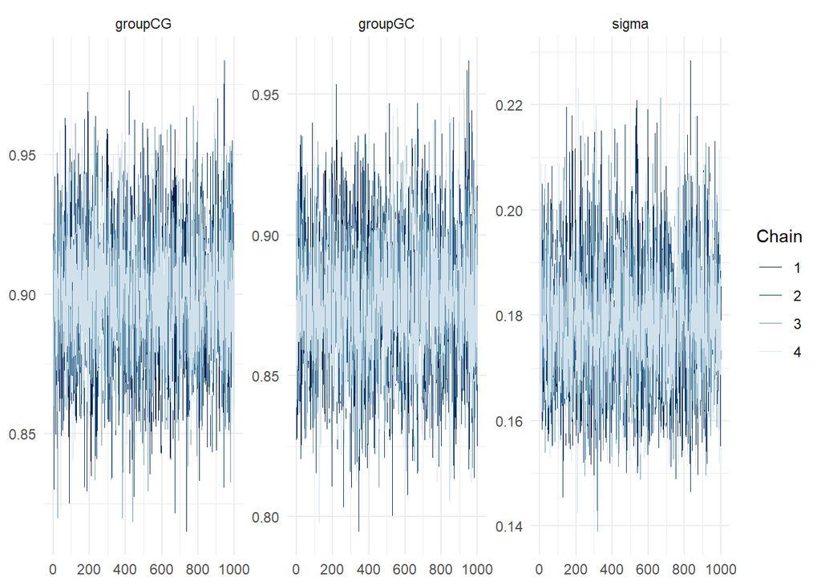

```r
plot(model, "trace")
```

```r
#plot(model, "hist")
```

```r
means <- modelbased::estimate_means(model, ci = ci_width, centrality = "median", ci_method = "hdi")
contrasts <- modelbased::estimate_contrasts(model, ci = ci_width, centrality = "median", ci_method = "hdi")
```

This plot shows the raw data (each point represents one student) as well as the estimated mean for each group (with 95% HDI).

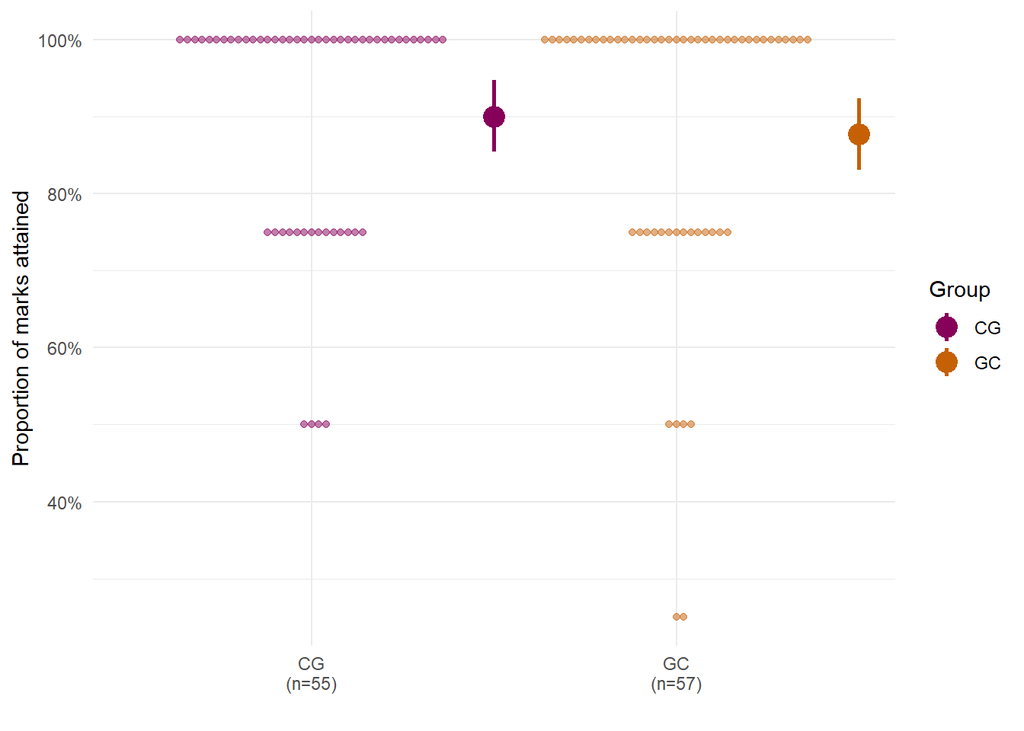

```r
FT_data  %>%
  ggplot(aes(x = group, y = marks_prop, colour = group)) +
  ggbeeswarm::geom_beeswarm(alpha = 0.5) +
  geom_pointrange(data = means, aes(x = group, y = Mean, ymin = CI_low, ymax = CI_high),
                  position = position_nudge(x = 0.5),
                  size = 1) +
  scale_x_discrete("", labels = FT_data %>% select(group, group_label) %>% distinct() %>% deframe()) +
  scale_y_continuous("Proportion of marks attained", labels = scales::percent) +
  scale_colour_manual("Group", values = groupcolours)
```

These are the estimated means (with 95% HDIs) for each group:

```r
means %>% basic_kable()
```

| group | Mean | CI_low | CI_high |
| --- | --- | --- | --- |
| CG | 0.8997533 | 0.8541558 | 0.9471343 |
| GC | 0.8771166 | 0.8306103 | 0.9241786 |

Both groups appear very similar.

## Contrasts

These are the estimated differences between each of the groups:

```r
contrasts %>% basic_kable()
```

| Level1 | Level2 | Difference | CI_low | CI_high | pd | ROPE_Percentage | Std_Difference |
| --- | --- | --- | --- | --- | --- | --- | --- |
| CG | GC | 0.0232764 | -0.0452244 | 0.0882438 | 0.76525 | 0.9895 | 0.1314596 |

We can also manually compute the contrasts by using `spread_draws` to sample from the posterior estimates.

```r
model_draws <- model %>%
  spread_draws(groupCG, groupGC, sigma) %>%
  mutate(
    CG_vs_GC_contrast = groupCG - groupGC,
    CG_vs_GC_effect = CG_vs_GC_contrast / sigma
  )
model_draws_long <- model_draws %>%
  pivot_longer(
    cols = starts_with("CG_vs_GC"),
    names_to = "parameter",
    names_prefix = "CG_vs_GC_",
    values_to = "est"
  )
model_hdi_summary <- model_draws_long %>%
  group_by(parameter) %>%
  median_hdi(est)
model_hdi_summary %>% basic_kable()
```

| parameter | est | .lower | .upper | .width | .point | .interval |
| --- | --- | --- | --- | --- | --- | --- |
| contrast | 0.0232764 | -0.0452244 | 0.0882438 | 0.95 | median | hdi |
| effect | 0.1300028 | -0.2556098 | 0.4884062 | 0.95 | median | hdi |

The following plot summarises these estimates, also showing a representation of the posterior distribution for the estimates as 100 dots. The default ROPE width of 0.1*sd is used for the difference (and 0.1 for the effect size).

(Note that the ROPE_Percentage returned by `estimate_contrasts` above is based on the ROPE being [-0.1, 0.1] rather than [-0.1*sd, 0.1*sd].)

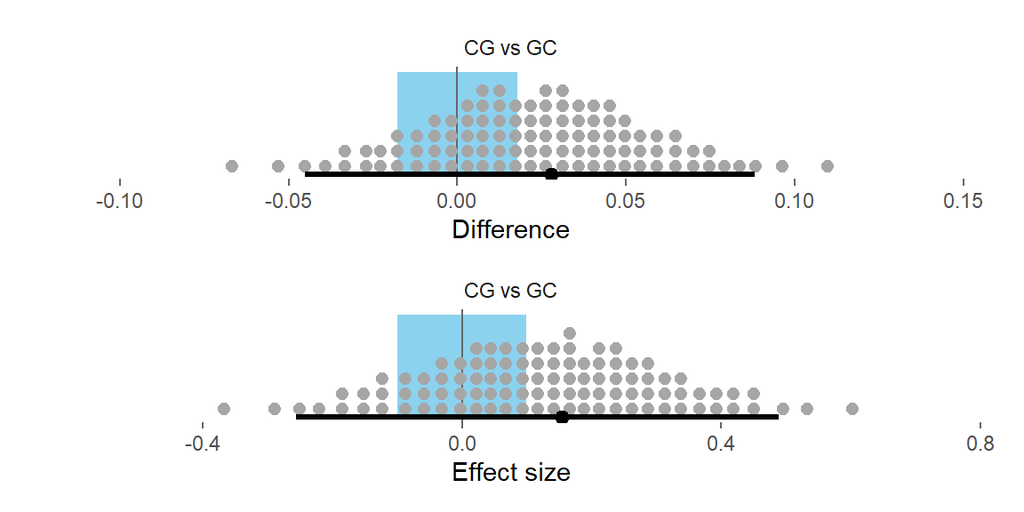

```r
rope_width = 0.1 * FT_data %>% summarise(marks_sd = sd(marks_prop)) %>% deframe()

p_diffs <- bind_rows(
    "CG vs GC" = model_draws %>% rename_with( ~ str_remove(., "CG_vs_GC_")),
    .id = "key"
  ) %>%
  ggplot(aes(x = contrast, y = 0)) +
  geom_rect(xmin = -rope_width, xmax = rope_width, ymin = 0, ymax = 1, fill = "skyblue", alpha = 0.1) +
  geom_vline(xintercept = 0, colour = "grey40") +
  stat_dotsinterval(
    point_interval = mode_hdi,
    .width = .95,
    slab_size = 0,
    quantiles = 100
  ) +
  scale_y_continuous(NULL, breaks = NULL) +
  expand_limits(x = c(-0.1, 0.1)) +
  xlab("Difference") +
  facet_wrap( ~ key, scales = "free_x") +
  theme(panel.grid = element_blank(),
        axis.ticks = element_line(color = "grey40"))

p_effsize <- bind_rows(
    "CG vs GC" = model_draws %>% rename_with( ~ str_remove(., "CG_vs_GC_")),
    .id = "key"
  ) %>%
  ggplot(aes(x = effect, y = 0)) +
  geom_rect(xmin = -0.1, xmax = 0.1, ymin = 0, ymax = 1, fill = "skyblue", alpha = 0.1) +
  geom_vline(xintercept = 0, colour = "grey40") +
  stat_dotsinterval(
    point_interval = mode_hdi,
    .width = .95,
    slab_size = 0,
    quantiles = 100
  ) +
  scale_y_continuous(NULL, breaks = NULL) +
  expand_limits(x = c(-0.1, 0.1)) +
  xlab("Effect size") +
  facet_wrap( ~ key, scales = "free_x") +
  theme(panel.grid = element_blank(),
        axis.ticks = element_line(color = "grey40"))

p_diffs / p_effsize
```

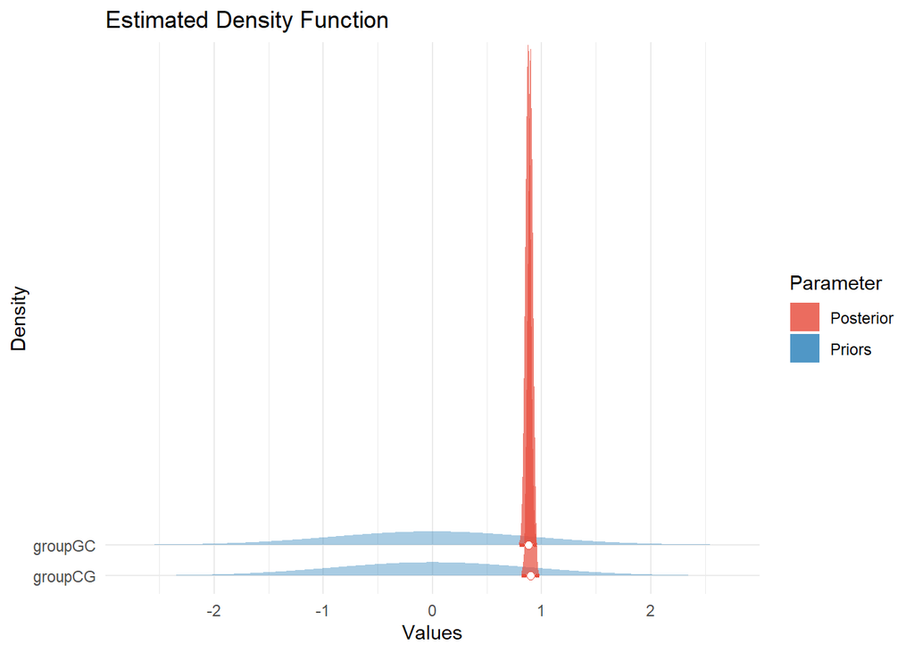

```r
result <- estimate_density(model)
plot(result, stack = FALSE, priors = TRUE)
```

```r
rope_result <- rope(model, ci = ci_width)
rope_result
```

|  | Parameter | CI | ROPE_low | ROPE_high | ROPE_Percentage | Effects | Component |
| --- | --- | --- | --- | --- | --- | --- | --- |
| 1 | groupCG | 95 | -0.01770609 | 0.01770609 | 0 | fixed | conditional |
| 2 | groupGC | 95 | -0.01770609 | 0.01770609 | 0 | fixed | conditional |

```r
modelbased::estimate_contrasts(model, ci = ci_width, centrality = "median", ci_method = "hdi", rope_range = c(-0.1, 0.1))
```

|  | Level1 | Level2 | Difference | CI_low | CI_high | pd | ROPE_Percentage | Std_Difference |
| --- | --- | --- | --- | --- | --- | --- | --- | --- |
| 1 | CG | GC | 0.02327635 | -0.04522435 | 0.08824383 | 0.76525 | 0.9895 | 0.1314596 |